title: “Video Game Analysis”  
author: “Ismail Khalil”  
date: “2022-11-01”  
output: github_document

# Capstone Project

## Summary

You are a junior data analyst working for a business intelligence consultant. You have been at your job for six months, and your boss feels you are ready for more responsibility. He has asked you to lead a project for a brand new client—this will involve everything from defining the business task all the way through presenting your data-driven recommendations. You will choose the topic, ask the right questions, identify a fresh dataset and ensure its integrity, conduct analysis, create compelling data visualizations, and prepare a presentation.

## Ask

Business Task: My client is the executive team from Nintendo, and they want me to analyze video game trends in the past to produce insights that will help them with their future products.

The dataset I will use for my analysis will be from Kaggle, and it is a dataset about video game sales greater than 100,000 copies from 1980 to 2016.

A link to the dataset can be found by [clicking here](https://www.kaggle.com/datasets/gregorut/videogamesales?pag=).

## Prepare

One of the limitations of this dataset is that it only goes up to 2016, and is not current. For the purposes of this project only this dataset will be used, but for a full analysis more current data is needed.

The data is organized in long format and there are no bias or credibility issues as the full process on how they got the data was detailed in their Kaggle description.

This data will help me derive insights because it has sales data related to a large range of companies as well as Nintendo games.

The data from vgchartz has good data integrity, but the data are estimates.

## Process

To start I will download the relevant libraries, load in the dataset, and then clean up the data that I choose to use for my analysis.

```r
install.packages('tidyverse')
```

```
## Error in install.packages : Updating loaded packages
```

```r
library('tidyverse')
```

```r
sales_data_df <- read_csv("vgsales.csv")
view(sales_data_df)
```

The sales columns are the number of copies sold in millions and not the revenue.

```r
glimpse(sales_data_df)
```

```
## Rows: 16,035
## Columns: 11
## $ Rank         <dbl> 1, 2, 3, 4, 5, 6, 7, 8, 9, 10, 11,…
## $ Name         <chr> "Wii Sports", "Super Mario Bros.",…
## $ Platform     <chr> "Wii", "NES", "Wii", "Wii", "GB", …
## $ Year         <chr> "2006", "1985", "2008", "2009", "1…
## $ Genre        <chr> "Sports", "Platform", "Racing", "S…
## $ Publisher    <chr> "Nintendo", "Nintendo", "Nintendo"…
## $ NA_Sales     <dbl> 41.49, 29.08, 15.85, 15.75, 11.27,…
## $ EU_Sales     <dbl> 29.02, 3.58, 12.88, 11.01, 8.89, 2…
## $ JP_Sales     <dbl> 3.77, 6.81, 3.79, 3.28, 10.22, 4.2…
## $ Other_Sales  <dbl> 8.46, 0.77, 3.31, 2.96, 1.00, 0.58…
## $ Global_Sales <dbl> 82.74, 40.24, 35.82, 33.00, 31.37,…
```

Cleaning the data to make sure it only has games from 1980 to 2016

```r
sales_data_df2 <- sales_data_df %>%
filter(sales_data_df$Year >= 1980, sales_data_df$Year <= 2016)
```

Each variable does not have any missing values

```r
sapply(sales_data_df2, function(x) sum(is.na(x)))
```

```
##         Rank         Name     Platform         Year
##            0            0            0            0
##        Genre    Publisher     NA_Sales     EU_Sales
##            0            0            0            0
##     JP_Sales  Other_Sales Global_Sales
##            0            0            0
```

After using the unique function as well as carefully looking through each of the columns, the dataset is now clean.

## Analyze & Share

I want to first find out which publisher had the highest global sales out of all the years in this data set

```r
global_sales_by_pub <- aggregate(sales_data_df2$Global_Sales, list(sales_data_df2$Publisher), FUN=sum)
colnames(global_sales_by_pub) <- c("Publisher", "Global_Sales")
```

The top five publishers in global sales from 1980 to 2016 are:

1. Nintendo
2. Electronic Arts (EA)
3. Activision
4. Sony Computer Entertainment
5. Ubisoft

I now want to find out which games in particular earned the highest global sales

```r
global_sales_by_game <- (aggregate(sales_data_df2$Global_Sales, list(sales_data_df2$Name), FUN=sum))
colnames(global_sales_by_game) <- c("Name", "Global_Sales")
```

It looks like the top five games for this time period is:

1. Wii Sports
2. Grand Theft Auto V
3. Super Mario Bros.
4. Tetris
5. Mario Cart Wii

All of these games were published by Nintendo except for Grand Theft Auto which was published by Take Two Interactive.

Now I want to see what genres are potentially on the rise by looking at global sales

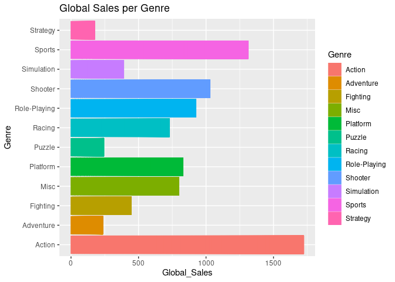

```r
ggplot(sales_data_df2, aes(x = Genre, y = Global_Sales,fill = Genre, color = Genre)) + geom_bar(stat = "identity") + coord_flip() + ggtitle( 'Global Sales per Genre')
```

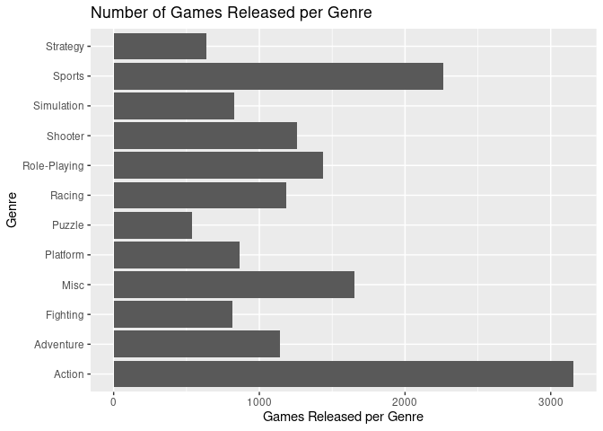

```r
ggplot(sales_data_df2, aes(x=Genre))+ geom_bar() + labs(y = "Games Released per Genre")+ coord_flip()+ ggtitle("Number of Games Released per Genre")
```

I now want to take a look at all the all the games Nintendo released and the genres that each of them were in.

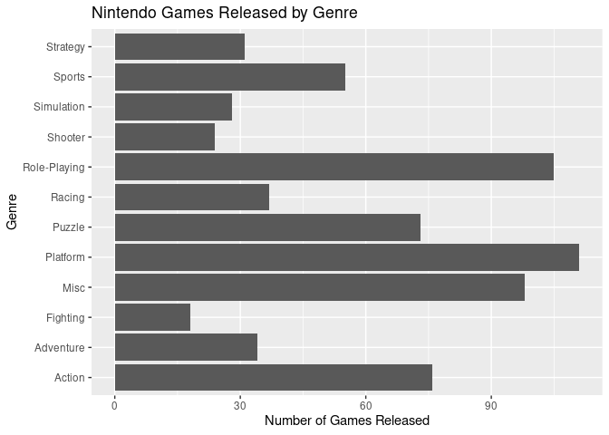

```r
nintendo_games_released <- sales_data_df2 %>% filter(Publisher== "Nintendo")
ggplot(nintendo_games_released, aes(x=Genre)) +geom_bar() + labs(y="Number of Games Released") + coord_flip() + ggtitle("Nintendo Games Released by Genre")
```

Nintendo has produced the most Platform games and the least Fighting games. Nintendo should increase the number of Shooter games that they are releasing because if you look at global sales then you can see that that is one of the most popular genres, but Nintendo is not making enough of those games. Nintendo has the possibility of taking more market share away from the games currently producing Shooter games.

I now want to see the top five publishers in the shooting genre and their global sales.

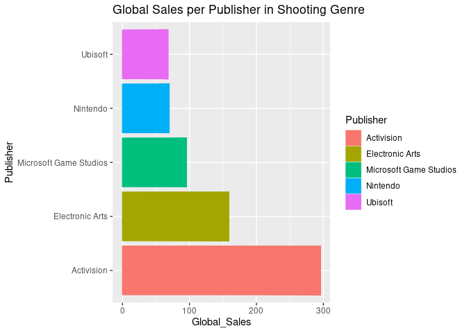

```r
shooter_games_released <- sales_data_df2 %>% filter(Genre== "Shooter" & (Publisher == "Nintendo" |Publisher == "Electronic Arts" |Publisher == "Activision" |Publisher == "Ubisoft" |Publisher == "Microsoft Game Studios" ))
ggplot(shooter_games_released, aes(x = Publisher, y = Global_Sales, fill = Publisher, color = Publisher)) + geom_bar(stat = "identity") + ggtitle("Global Sales per Publisher in Shooting Genre") + coord_flip()
```

## Act

To conclude, I have three insights I want to share with the Nintendo executive team: Nintendo is the number one publisher in terms of global sales from 1980 to 2016. The game that earned the highest global sales in this time period was Wii Sports, which means that Nintendo should possibly publish a game similar to that in the future. Lastly, Nintendo should stay out of the shooting genre unless they can create a game that is on par with the likes of games, such as Activision’s Call of Duty franchise.